# Text Analyis

# Your mission

Perform text analysis.

## Okay, I need more information

Perform sentiment analysis or topic modeling using text analysis methods as demonstrated in the pre-class work and in the readings.

## Okay, I need even more information.

Do the above. Can’t think of a data source?

Analyze the text for sentiment OR topic. **You do not need to do both**. The datacamp courses and [Tidy Text Mining with R](http://tidytextmining.com/) are good starting points for templates to perform this type of analysis, but feel free to *expand beyond these examples*.

# Timelines and Task

We will spend the next 2 weeks working on analyzing textual data in R. You will do the following:

- Start with some text based data.
- Clean data and prepare it for analysis
- Ask questions about the data
- Answer these questions with the data using tables and graphics
- Each group member must have their own unique question that they code the answer for.

## Package installation

```r
#install.packages("janeaustenr")  # for book by janeaustenr
#install.packages("gutenbergr")  # for free ebooks
#install.packages("dplyr")  # for data manipulation
#install.packages("stringr")  # for string manupulation
#install.packages("tidytext")  # for text mining
#install.packages("SnowballC") # for text stemming
#install.packages("ggplot2")  # for text stemming
#install.packages("wordcloud") # word-cloud generator
#install.packages("RColorBrewer") # color palettes
#install.packages("ggrepel") # ggrepel
#install.packages("igraph") # ggrepel
#install.packages("ggraph") # ggrepel
#install.packages("XML") # for web scraping
#install.packages("rebus") # for regex
#install.packages("R.utils")
#install.packages("topicmodels")

if (packageVersion("devtools") < 1.6) {
  install.packages("devtools")
}
devtools::install_github("bradleyboehmke/harrypotter")
```

## Loading required packages

```r
library(janeaustenr)
library(gutenbergr)
library(dplyr)
library(stringr)
library(tidytext)
library(ggplot2)
library(wordcloud)
library(RColorBrewer)
library(harrypotter)
library(tidyr)
library(ggrepel)
library(RColorBrewer)
library(igraph)
library(ggraph)
library(rebus)
library(topicmodels)
library(DT)          #Datatable
```

## Reusable functions

```r
# this function returns ggplot theme definition ~ this will prevent code duplication
uniform_ggplot_theme <- function(base_size = 12, base_family = "sans"){
  theme_grey(base_size = base_size, base_family = base_family) +
    theme(
      axis.text = element_text(size = 12),
      axis.text.x = element_text(angle = 90, vjust = 0.5, hjust = 1),
      axis.title = element_text(size = 14),
      panel.grid.major = element_line(color = "grey"),
      panel.grid.minor = element_blank(),
      panel.background = element_rect(fill = "aliceblue"),
      strip.background = element_rect(fill = "lightgrey", color = "grey", size = 1),
      strip.text = element_text(face = "bold", size = 12, color = "navy"),
      legend.position = "bottom",
      legend.background = element_blank(),
      panel.margin = unit(.5, "lines"),
      panel.border = element_rect(color = "grey", fill = NA, size = 0.5)
    )
}
```

## Merging data from different sources

Let’s start by importing and merging all necessary data required for this analysis

```r
# Fetch Book metadata from theGuardian.com e.g publisher, ranking, sales, author e.t.c
bookMetadata <- read.csv("https://docs.google.com/spreadsheets/d/1dhxblR1Vl7PbVP_mNhwEa3_lfUWiF__xSODLq1W83CA/export?format=csv&id=1dhxblR1Vl7PbVP_mNhwEa3_lfUWiF__xSODLq1W83CA&gid=0")

#web scrape main characters of Harry Potter Series from
library(XML)
library(RCurl)
# download harry potter wikipedia page
hp_wikipedia_site = readLines('https://en.wikipedia.org/wiki/List_of_Harry_Potter_characters')
#define custom stop word used in HP character names data cleaning
custom_stop_words <-  c('Wikipedia','Wikimedia','The','Puppet','Hogwarts','Stories','Through')
# read entire hp_wikipedia_site
harrypotter_characters <- str_match( hp_wikipedia_site, capture (UPPER %R% one_or_more(WRD)) %R% SPC %R% capture(UPPER %R% one_or_more(WRD))) %>%
  as.data.frame() %>% # convert to data frame for easy manipulation
  na.exclude()%>% # remove missing data
  setNames(c( "FullName", "FirstName", "LastName")) %>% # set column names
  arrange(FullName) %>% # arrange
  filter(!FirstName%in%custom_stop_words) %>% # clean data by first name
  filter(!LastName%in%custom_stop_words) %>% # clean data by last name
  unique()




# Combine all The Harry Potter books into 1 dataframe and add column which will be used a reference "Title"

book1 <- data_frame(Title="Harry Potter and the Philosopher's Stone", text=philosophers_stone)
book2 <- data_frame(Title="Harry Potter and the Chamber of Secrets", text=chamber_of_secrets)
book3 <- data_frame(Title="Harry Potter and the Prisoner of Azkaban", text=prisoner_of_azkaban)
book4 <- data_frame(Title="Harry Potter and the Goblet of Fire", text=goblet_of_fire)
book5 <- data_frame(Title="Harry Potter and the Order of the Phoenix", text=order_of_the_phoenix)
book6 <- data_frame(Title="Harry Potter and the Half-blood Prince", text=half_blood_prince)
book7 <- data_frame(Title="Harry Potter and the Deathly Hallows", text=deathly_hallows)

# Join BookMetadata and HarryPotter dfs by "Title"
harrypotterSeries <- rbind(book1,book2, book3, book4, book5, book6, book7) %>%
  group_by(Title) %>%
  mutate(Chapter = row_number())%>% # add chapter
  ungroup()%>%
  unnest_tokens(sentence, text, token = "sentences") %>%
  mutate(line = row_number()) # add sentences

head(harrypotterSeries)
```

```
## # A tibble: 6 x 4
##                                     Title Chapter
##                                     <chr>   <int>
## 1 Harry Potter and the Chamber of Secrets       1
## 2 Harry Potter and the Chamber of Secrets       1
## 3 Harry Potter and the Chamber of Secrets       1
## 4 Harry Potter and the Chamber of Secrets       1
## 5 Harry Potter and the Chamber of Secrets       1
## 6 Harry Potter and the Chamber of Secrets       1
## # ... with 2 more variables: sentence <chr>, line <int>
```

## Cleaning Data

1. Restructure it in the one-token-per-row format,

```r
harrypotter_tokenized <- harrypotterSeries %>%
  unnest_tokens(word, sentence)

harrypotter_tokenized %>%
  select(Title, Chapter, word) %>%
  head()
```

```
## # A tibble: 6 x 3
##                                     Title Chapter     word
##                                     <chr>   <int>    <chr>
## 1 Harry Potter and the Chamber of Secrets       1      the
## 2 Harry Potter and the Chamber of Secrets       1    worst
## 3 Harry Potter and the Chamber of Secrets       1 birthday
## 4 Harry Potter and the Chamber of Secrets       1      not
## 5 Harry Potter and the Chamber of Secrets       1      for
## 6 Harry Potter and the Chamber of Secrets       1      the
```

2. Remove stop words; stop words are words that are not useful for an analysis, typically extremely common words such as “the”, “of”, “to”,

```r
harrypotter_clean_tokens <- harrypotter_tokenized %>%
  anti_join(stop_words)  #remove stop words like "the"
```

## Quantitative and Sentimental Analysis

### Q1. what is the most important charecter based on how much it was mentioned

[figure not shown]

```r
harrypotter_clean_tokens %>%
  mutate(id = R.utils::capitalize(word)) %>%
  inner_join(harrypotter_characters, by =c(id = "FirstName") ) %>%
  count(FullName,sort= TRUE)  %>%
  top_n(20) %>%
  ggplot() +
    geom_bar(mapping = aes(x = reorder(FullName, n), fill=FullName,
                           y = n),alpha = 0.8, stat = "identity") +
    labs(x = NULL, y = "Count") +
    coord_flip() + ggtitle("Harry Potter Top 20 Characters")+
    theme(legend.position="none")
```

### Q2. what is the most scariest book based on sentiment analysis ?

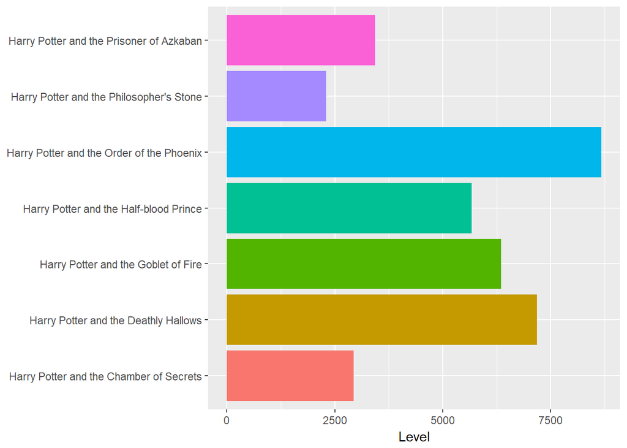

```r
hp_negative_sentiment<-harrypotter_clean_tokens%>%
  inner_join(get_sentiments("bing"), by = "word") %>% # join sentiment
  group_by(Title)%>% # make each row  abook
  count(sentiment, sort = TRUE)%>% # count sentiment
  filter(sentiment=="negative")  #filter by negative sentiment



#plot the graph of harrypotter_clean_tokens
hp_negative_sentiment %>%
  ggplot(aes(Title,n, fill=Title)) +
  geom_bar(stat="identity")+
  labs(x = NULL, y = "Level") +
  theme(legend.position="none") +
  coord_flip()
```

```r
# Using bing lexicon, Harry Potter and the Order of the Phoenix is the scariest with about 8k negative sentiments

# supporting data table
datatable(hp_negative_sentiment)
```

|  | Title | sentiment | n |
| --- | --- | --- | --- |
| 1 | Harry Potter and the Order of the Phoenix | negative | 8670 |
| 2 | Harry Potter and the Deathly Hallows | negative | 7183 |
| 3 | Harry Potter and the Goblet of Fire | negative | 6349 |
| 4 | Harry Potter and the Half-blood Prince | negative | 5670 |
| 5 | Harry Potter and the Prisoner of Azkaban | negative | 3433 |
| 6 | Harry Potter and the Chamber of Secrets | negative | 2936 |
| 7 | Harry Potter and the Philosopher's Stone | negative | 2292 |

### Q3. What the top ten used words in exception to stop words ?

```r
word_count <- harrypotter_clean_tokens %>%
  count(word, sort = TRUE) %>%
  mutate(word = reorder(word, n))

# supporting data table
datatable(word_count)
```

|  | word | n |
| --- | --- | --- |
| 1 | harry | 16717 |
| 2 | ron | 5784 |
| 3 | hermione | 4960 |
| 4 | dumbledore | 2882 |
| 5 | looked | 2344 |
| 6 | professor | 2008 |
| 7 | hagrid | 1735 |
| 8 | time | 1716 |
| 9 | wand | 1641 |
| 10 | eyes | 1610 |

[output cut: 22825 more lines]

[figure not shown]

```r
# Visualization of the most common words
word_count_gt_600 <- word_count %>%
  filter(n > 600)


# plot using word cloud

wordcloud(words = word_count_gt_600$word, freq = word_count_gt_600$n, min.freq = 1,
          random.order=FALSE, rot.per=0.35,
          colors=brewer.pal(8, "Dark2"))
```